# Practical Machine Learning - Course Project

Maryam Kabiri

May 25, 2016

# Prediction Assignment Writeup

## Background

Using devices such as Jawbone Up, Nike FuelBand, and Fitbit it is now possible to collect a large amount of data about personal activity relatively inexpensively. These type of devices are part of the quantified self movement - a group of enthusiasts who take measurements about themselves regularly to improve their health, to find patterns in their behavior, or because they are tech geeks. One thing that people regularly do is quantify how much of a particular activity they do, but they rarely quantify how well they do it. In this project, your goal will be to use data from accelerometers on the belt, forearm, arm, and dumbell of 6 participants. They were asked to perform barbell lifts correctly and incorrectly in 5 different ways. More information is available from the website here: http://groupware.les.inf.puc-rio.br/har (see the section on the Weight Lifting Exercise Dataset).

## Data Sources

The training data for this project are available here:

https://d396qusza40orc.cloudfront.net/predmachlearn/pml-training.csv

The test data are available here:

https://d396qusza40orc.cloudfront.net/predmachlearn/pml-testing.csv

The data for this project come from this source: http://groupware.les.inf.puc-rio.br/har. If you use the document you create for this class for any purpose please cite them as they have been very generous in allowing their data to be used for this kind of assignment.

## What you should submit

The goal of your project is to predict the manner in which they did the exercise. This is the “classe” variable in the training set. You may use any of the other variables to predict with. You should create a report describing how you built your model, how you used cross validation, what you think the expected out of sample error is, and why you made the choices you did. You will also use your prediction model to predict 20 different test cases.

## Reproducibility

Installing packages, loading libraries, and setting the seed to produce the same results.

```r
library(caret)
```

```r
library(rpart)
library(rpart.plot)
library(rattle)
library(randomForest)
set.seed(123456)
```

## Getting and cleaning data

The dataset are downloaded from the following URLs into the current working directory.

https://d396qusza40orc.cloudfront.net/predmachlearn/pml-training.csv

https://d396qusza40orc.cloudfront.net/predmachlearn/pml-testing.csv

```r
train<-read.csv("pml-training.csv", na.strings = c("NA", "DIV/0!", ""))
test<-read.csv("pml-testing.csv", na.strings = c("NA", "DIV/0!", ""))
```

```r
dim(train)
```

```
## [1] 19622   160
```

```r
dim(test)
```

```
## [1]  20 160
```

Both train and test datasets have 160 variables. If we look at the structure of the files, wee see that some of the variables have lots of NA’s. The next step is to remove the variables with more than 75% threshold of NA’s.

```r
train_data<-sapply(colnames(train), function(x) if(sum(is.na(train[,x]))>0.75*nrow(train)) {
  return(T)
} else{
    return(F)
  }
)
```

```r
train<-train[, !train_data]
```

The variables such as username, timetamp, etc. are not useful for the prediction. Then the first six variables have been removed from dataset.

```r
train<-train[, -(1:6)]
```

```r
dim(train)
```

```
## [1] 19622    54
```

After cleaning the dataset, there are only 54 variables. Next step is creating partition with the train dataset.

```r
train_set<-createDataPartition(y=train$classe, p=0.7, list=FALSE)
training<-train[train_set,]
testing<-train[-train_set,]
```

```r
dim(training)
```

```
## [1] 13737    54
```

```r
dim(testing)
```

```
## [1] 5885   54
```

# Prediction Models

## 1) Random Forest

```r
model_1<-randomForest(classe~., data=training, method="class")
predict_1<-predict(model_1, testing, type="class")
confusionMatrix(predict_1, testing$classe)
```

```
## Confusion Matrix and Statistics
##
##           Reference
## Prediction    A    B    C    D    E
##          A 1674    5    0    0    0
##          B    0 1134    8    0    0
##          C    0    0 1018    7    0
##          D    0    0    0  957    1
##          E    0    0    0    0 1081
##
## Overall Statistics
##
##                Accuracy : 0.9964
##                  95% CI : (0.9946, 0.9978)
##     No Information Rate : 0.2845
##     P-Value [Acc > NIR] : < 2.2e-16
##
##                   Kappa : 0.9955
##  Mcnemar's Test P-Value : NA
##
## Statistics by Class:
##
##                      Class: A Class: B Class: C Class: D Class: E
## Sensitivity            1.0000   0.9956   0.9922   0.9927   0.9991
## Specificity            0.9988   0.9983   0.9986   0.9998   1.0000
## Pos Pred Value         0.9970   0.9930   0.9932   0.9990   1.0000
## Neg Pred Value         1.0000   0.9989   0.9984   0.9986   0.9998
## Prevalence             0.2845   0.1935   0.1743   0.1638   0.1839
## Detection Rate         0.2845   0.1927   0.1730   0.1626   0.1837
## Detection Prevalence   0.2853   0.1941   0.1742   0.1628   0.1837
## Balanced Accuracy      0.9994   0.9970   0.9954   0.9963   0.9995
```

## 2)Decision Tree

```r
model_2<-rpart(classe~.,data=training, method = "class")
predict_2<-predict(model_2, testing, type="class")
confusionMatrix(predict_2, testing$classe)
```

```
## Confusion Matrix and Statistics
##
##           Reference
## Prediction    A    B    C    D    E
##          A 1499  183   40   61   44
##          B   64  706   91   87  133
##          C   21   68  818  142   86
##          D   71  145   44  631  129
##          E   19   37   33   43  690
##
## Overall Statistics
##
##                Accuracy : 0.7381
##                  95% CI : (0.7267, 0.7493)
##     No Information Rate : 0.2845
##     P-Value [Acc > NIR] : < 2.2e-16
##
##                   Kappa : 0.6679
##  Mcnemar's Test P-Value : < 2.2e-16
##
## Statistics by Class:
##
##                      Class: A Class: B Class: C Class: D Class: E
## Sensitivity            0.8955   0.6198   0.7973   0.6546   0.6377
## Specificity            0.9221   0.9210   0.9348   0.9210   0.9725
## Pos Pred Value         0.8205   0.6531   0.7207   0.6186   0.8394
## Neg Pred Value         0.9569   0.9099   0.9562   0.9316   0.9226
## Prevalence             0.2845   0.1935   0.1743   0.1638   0.1839
## Detection Rate         0.2547   0.1200   0.1390   0.1072   0.1172
## Detection Prevalence   0.3105   0.1837   0.1929   0.1733   0.1397
## Balanced Accuracy      0.9088   0.7704   0.8660   0.7878   0.8051
```

Decision tree with fancy view:

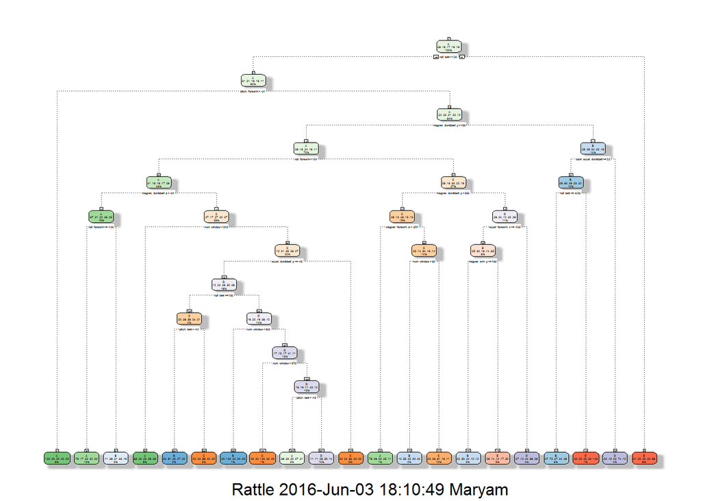

```r
fancyRpartPlot(model_2)
```

# Conclusion

It is obviouse that Random Forest model yields better results.

Finally, the Random Forest model is used to predict the 20 different test cases.

```r
predict_test<-predict(model_1, newdata=test)
predict_test
```

```
##  1  2  3  4  5  6  7  8  9 10 11 12 13 14 15 16 17 18 19 20
##  B  A  B  A  A  E  D  B  A  A  B  C  B  A  E  E  A  B  B  B
## Levels: A B C D E
```